# Laboratorio 4: "Diagramas de ojo e Interferencia entre símbolos"

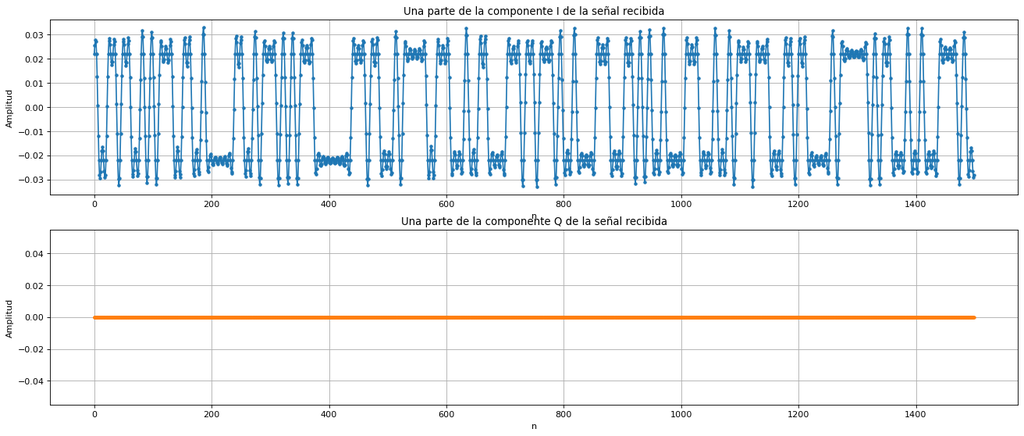

```python
#------------------------------- Received I component -------------------------------
# Plot time domain
plt.figure(figsize=(20,8), dpi= 80, facecolor='w', edgecolor='k')
plt.subplot(2,1,1)
plt.plot(np.real(rxSignal[0:1500]), '.-')
plt.xlabel('n')
plt.ylabel('Amplitud')
plt.title('Una parte de la componente I de la señal recibida')
plt.grid()

#------------------------------- Received Q component -------------------------------
# Plot time domain
plt.subplot(2,1,2)
plt.plot(np.imag(rxSignal[0:1500]), '.-C1')
plt.xlabel('n')
plt.ylabel('Amplitud')
plt.title('Una parte de la componente Q de la señal recibida')
plt.grid()
plt.show()
```

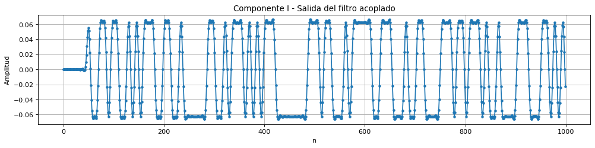

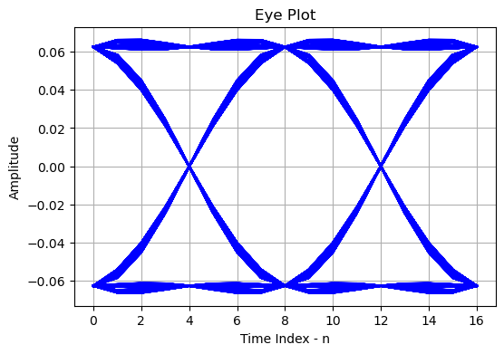

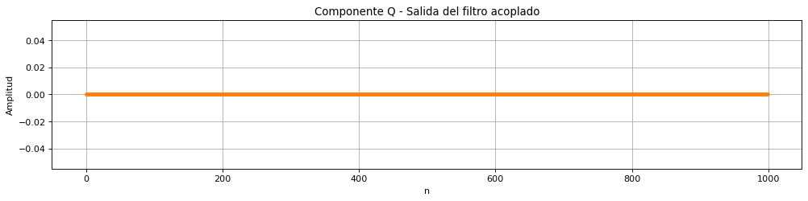

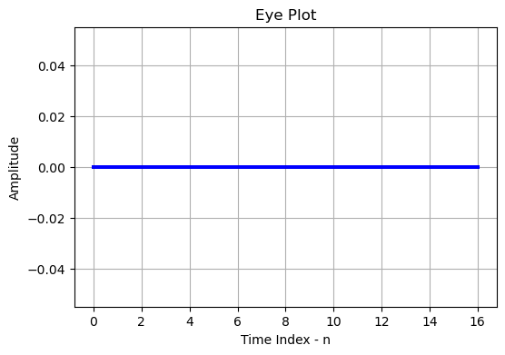

```python
#------------------------------- Filtered I component -------------------------------

iRxFilSignal = np.convolve(np.real(rxSignal),matchedFilter)
plt.figure(figsize=(15, 3), dpi= 80, facecolor='w', edgecolor='k')
plt.plot(iRxFilSignal[0:1000],'.-')
plt.title('Componente I - Salida del filtro acoplado')
plt.ylabel('Amplitud')
plt.xlabel('n')
plt.grid()
plt.show()

corr     = signal.correlate(np.real(txSignal), np.real(rxSignal), mode="full")
lags     = signal.correlation_lags(len(txSignal), len(rxSignal), mode="full")
Rmax_pos = np.argmax(corr)

#------------------------------- Eye Diagram -------------------------------

i_Signal = iRxFilSignal[-lags[Rmax_pos]+2*span*sps:-lags[Rmax_pos]+len(txSignal)-2*span*sps]
L        = sps*2           # display length in samples (usually two symbols)
S        = 0               # start index
dc.eye_plot(i_Signal,L,S)
plt.show()

#------------------------------- Filtered Q component -------------------------------

qRxFilSignal = np.convolve(np.imag(rxSignal),matchedFilter)
plt.figure(figsize=(15, 3), dpi= 80, facecolor='w', edgecolor='k')
plt.plot(qRxFilSignal[0:1000],'.-C1')
plt.title('Componente Q - Salida del filtro acoplado')
plt.ylabel('Amplitud')
plt.xlabel('n')
plt.grid()
plt.show()

#------------------------------- Eye Diagram -------------------------------

q_Signal = qRxFilSignal[-lags[Rmax_pos]+2*span*sps:-lags[Rmax_pos]+len(txSignal)-2*span*sps]
dc.eye_plot(q_Signal,L,S)
plt.show()
```

```python
# Since it is not possible to turn off Tx, it is configured to transmit at low power and on a different frequency than Rx.
sdr.tx_destroy_buffer()
sdr.tx_hardwaregain_chan0  = -70
sdr.rx_lo                  = int(2400e6)
sdr.tx(np.zeros(1024))
```

```python
# Destroy radio object
del(sdr)
```

## Consignas

1. Partiendo de la configuración por defecto (loopback digital) y para un $\beta$ del filtro coseno realzado igual a 1, 0.75, 0.5 y 0.25:
   1. ¿Como impacta el valor de $\beta$ en la respuesta al impulso del filtro?
   2. ¿Como impacta el valor de $\beta$ en la respuesta en frecuencia del filtro? y ¿Cuando el sistema es más inmune a un posible ruido gaussiano blanco?
   3. Para los distintos valores de $\beta$ ¿Se observa ISI en el diagrama de ojo para el instante de muestreo ideal? Justifique su respuesta.
   4. Analizando el diagrama de ojo para valores de $\beta$ cada vez mas pequeños ¿el sistema se vuelve más o menos sensible a un error en la fase del sincronismo? Justifique su respuesta.
2. Partiendo de la configuración por defecto (loopback digital) y para un $\beta = 0$ ¿Que es posible deducir del diagrama de ojo? y ¿Que filtro queda conformado para este valor de $\beta$?
3. Para una $\beta = 0.25$ y para cantidades de taps del filtro de $12 T_{symb}$, $8 T_{symb}$, $6 T_{symb}$ y $4 T_{symb}$ ¿Se produce algún tipo de pérdida de desempeño en el sistema? ¿A qué es debido?
4. Configurando el sistema con un loopback desactivado (la señal sale e ingresa por antena) y un $\beta = 1$ ¿que conclusiones puede obtener al comparar este diagrama de ojo con el observando para el caso de loopback digital? Tenga en cuenta que posiblemente deba realizar varios intentos hasta obtener un diagrama de ojo adecuado.
5. Una forma de reducir la relación señal a ruido (SNR) en la entrada del receptor es dismimuyendo la potencia de la señal de salida del transmisor, esto es haciendo cada vez más negativo el valor de "TxAtten". ¿Que conclusiones puede obtener de la observación del diagrama de ojo a medida que disminuye esta SNR con el sistema configurado con loopback en RF?
6. Diseñe un código que reemplace el armado del diagrama de ojo realizado por la función "dc.eye_plot".

## Respuestas

### Como impacta en el sistema los distintos valores de $\beta$

**Para $\beta = 1$:**

El impacto de $\beta$ en la respuesta al impuslo lo podemos ver en el primer subplot del bloque "Root Raised Cosine Filter Design". Lo que se grafica originalmente en el código provisto es `rcFilter`, o sea el coseno realzado completo (la convolución de RCC con el filtro acoplado), no la RCC sola. Agregamos el plot de RCC para analizarlo también.

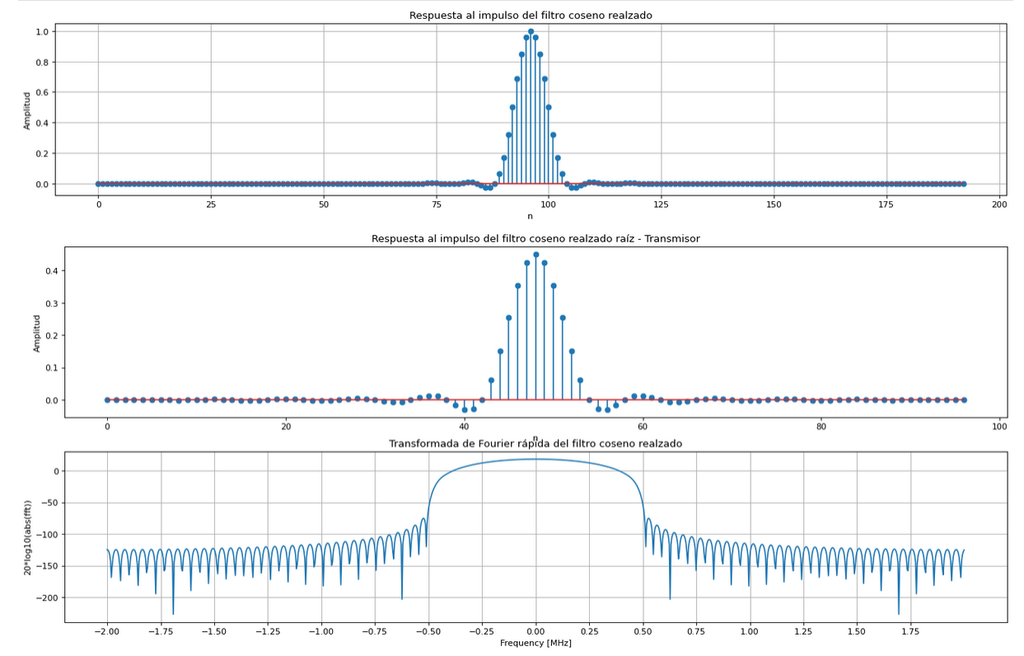

Para el gráfico de **Respuesta al impulso del coseno realzado** (`rcFilter`):

- El pico vale 1 en el centro ($n \approx 96$). Esto confirma que la RRC está normalizada a energía unitaria: El valor central del coseno realzado es $R_\psi(0)=||\psi||²=1$. Es la normalización que pide Nyquist.
- Cruza por cero en los múltiplos de T (con T = `sps` = 8 muestras) a ambos lados del centro. Esto es la propiedad de Nyquist, en los instantes de muestreo distintos del central, el pulso vale cero, así no hay interferencia entre los símbolos.
- Con $\beta = 1$ el pulso decae rápido y los lóbulos laterales son muy chicos. Esto es característico de un $\beta$ grande: rápida caída en el tiempo.

Para el gráfico de Respuesta al impuslo de la RRC sola (agregado por nosotros):

- El pico vale ~0.45, no 1, y el pulso oscila más, es decir, tienen lóbuos laterales más marcados que el coseno realzado.
- La RRC sola no tiene los cruces por cero limpios en los múltiplos de T. No cumple Nyquist por si misma. Solo la convolución de la dos RRC (Tx + Rx) genera el coseno realzado que si cumple Nyquist y tiene los cruces por cero correctos.

**Respuesta en Frecuencia del coseno realzado**:

- La banda de paso llega hasta $\pm 0.5\text{ MHz}$
- Con $\beta = 1$ se tiene el máximo exceso de ancho de banda posible. La transición tipo coseno ocupa toda la banda, sin zona plana. Por eso la forma de un coseno realzado "puro".
- Los lóbulos lateras están muy abajo (entre -100 y -150 dB), lo que muestra muy buena contención fuera de banda. Esto se relaciona con que $\beta = 1$ da decaimiento rápido en el tiempo.

Cuando bajemos los valores de $\beta$ (0.75, 0.5, 0.25), veremos que el pulso se ensancha, decae más lento y oscilará más (lóbulos más grandes).

Para la respuesta en frecuencia al bajar los valores de $\beta$ el espectro se irá angostando hacía el mínimo de Nyquist (0.25 MHz). **Si se angosta la banda entra menos pontencia de ruido blanco al receptor, por lo tanto es más inmune al AWGN.** El sistema es más inmune al ruido con $\beta$ más pequeño.

**Para $\beta = 0.75$**:

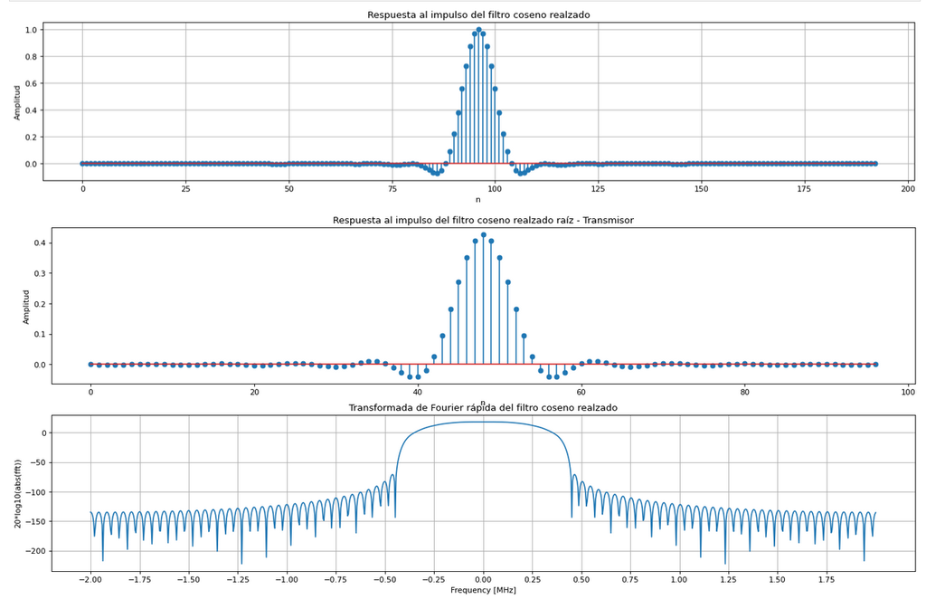

**Para $\beta = 0.5$:**

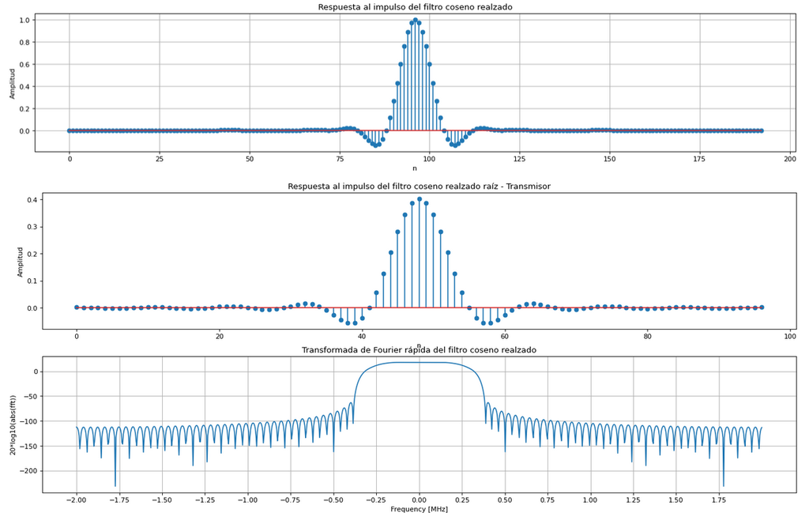

**Para $\beta = 0.25$:**

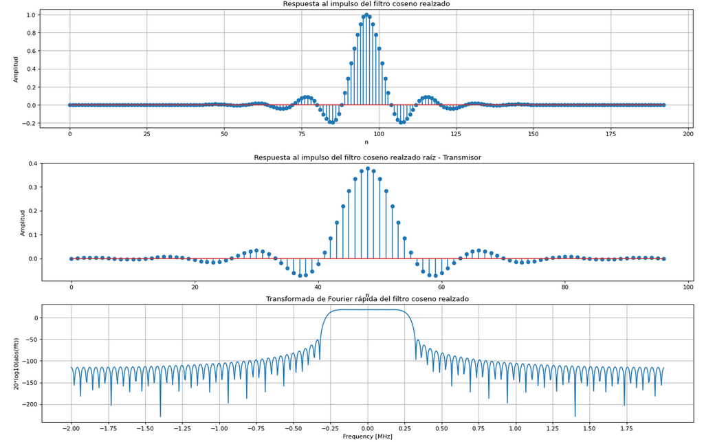

Podemos ver como a medida que disminuimos $\beta$ el pulso decae más lento y oscila más. También vemos que la respuesta en frecuencia se angosta, acercándose al ancho de banda mínimo de Nyquist.